# Homework 1

## Problem 1

Problem 1: (7 points) ISLR Chapter 2 Problem 9. This problem is an exploratory analysis of the Auto dataset. The dataset is available on Webcourses in the file Auto.csv Auto.csv. This dataset is referenced in the text of both Chapters 2 and 3 and you can look at the information there as a guideline. One important thing to note is that you should omit rows with missing entries using the na.omit() function in R or the or the df.dropna() function in pandas, where df is your dataframe. (Note: In general, omitting NA values might bias your results. But data imputation can be involved so for now we will just remove missing entries).

1. This exercise involves the Auto data set studied in the lab. Make sure that the missing values have been removed from the data.

```python
import pandas as pd;
file_path = 'C:/Users/danma/Downloads/STA 4364/Assigment 1/Auto.csv'
df = pd.read_csv(file_path)
#omiting NA values
df.dropna()
#could not set horsepower to integer because of non integer values identified in column '?'
df = df[df['horsepower'] != '?']
#reassigning horsepower column as an integer column
df['horsepower'] = df['horsepower'].astype(int)
#prints dataframe head
df.head()
```

|  | mpg | cylinders | displacement | horsepower | weight | acceleration | year | origin | name |
| --- | --- | --- | --- | --- | --- | --- | --- | --- | --- |
| 0 | 18.0 | 8 | 307.0 | 130 | 3504 | 12.0 | 70 | 1 | chevrolet chevelle malibu |
| 1 | 15.0 | 8 | 350.0 | 165 | 3693 | 11.5 | 70 | 1 | buick skylark 320 |
| 2 | 18.0 | 8 | 318.0 | 150 | 3436 | 11.0 | 70 | 1 | plymouth satellite |
| 3 | 16.0 | 8 | 304.0 | 150 | 3433 | 12.0 | 70 | 1 | amc rebel sst |
| 4 | 17.0 | 8 | 302.0 | 140 | 3449 | 10.5 | 70 | 1 | ford torino |

(a) Which of the predictors are quantitative, and which are qualitative?

Quantitative: mpg, displacement, horsepower, weight, acceleration  
Qualitative: cylinders, year, origin, name

(b) What is the range of each quantitative predictor? You can answer this using the range() function.

```python
#showing range with minimums and maximums
df.describe()[['mpg', 'displacement', 'horsepower', 'weight', 'acceleration']].loc[['min', 'max']]
```

|  | mpg | displacement | horsepower | weight | acceleration |
| --- | --- | --- | --- | --- | --- |
| min | 9.0 | 68.0 | 46.0 | 1613.0 | 8.0 |
| max | 46.6 | 455.0 | 230.0 | 5140.0 | 24.8 |

(c) What is the mean and standard deviation of each quantitative predictor?

```python
df.describe()[['mpg', 'displacement', 'horsepower', 'weight', 'acceleration']].loc[['mean', 'std']]
```

|  | mpg | displacement | horsepower | weight | acceleration |
| --- | --- | --- | --- | --- | --- |
| mean | 23.445918 | 194.411990 | 104.469388 | 2977.584184 | 15.541327 |
| std | 7.805007 | 104.644004 | 38.491160 | 849.402560 | 2.758864 |

(d) Now remove the 10th through 85th observations. What is the range, mean, and standard deviation of each predictor in the subset of the data that remains?

```python
#starting at 9 since df indices start at 0
dfsub = df.drop(df.index[9:84], axis=0)
dfsub.describe()[['mpg', 'displacement', 'horsepower', 'weight', 'acceleration']].loc[['mean', 'std', 'min', 'max']]
```

|  | mpg | displacement | horsepower | weight | acceleration |
| --- | --- | --- | --- | --- | --- |
| mean | 24.368454 | 187.753943 | 100.955836 | 2939.643533 | 15.718297 |
| std | 7.880898 | 99.939488 | 35.895567 | 812.649629 | 2.693813 |
| min | 11.000000 | 68.000000 | 46.000000 | 1649.000000 | 8.500000 |
| max | 46.600000 | 455.000000 | 230.000000 | 4997.000000 | 24.800000 |

(e) Using the full data set, investigate the predictors graphically, using scatterplots or other tools of your choice. Create some plots highlighting the relationships among the predictors. Comment on your findings.

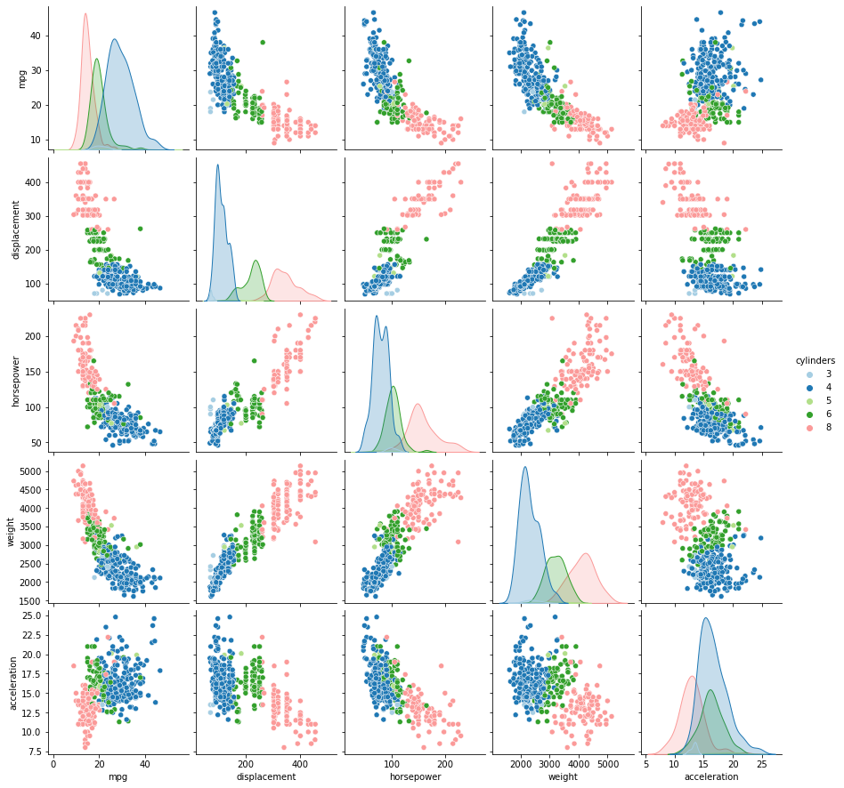

```python
import seaborn as sns
sns.pairplot(df, vars=['mpg', 'displacement', 'horsepower', 'weight', 'acceleration'], hue='cylinders', palette='Paired', kind='scatter')
#year, origin, name have no color identification assumptions/usage
#sns.pairplot(df, vars=['mpg', 'displacement', 'horsepower', 'weight', 'acceleration'], hue='year', palette='Paired', kind='scatter')
#sns.pairplot(df, vars=['mpg', 'displacement', 'horsepower', 'weight', 'acceleration'], hue='origin', palette='Paired', kind='scatter')
#sns.pairplot(df, vars=['mpg', 'displacement', 'horsepower', 'weight', 'acceleration'], hue='name', palette='Paired', kind='scatter')
```

**Vehicles with higher Displacement: have lower MPG, higher Horsepower, higher Weight. Resulting in the relationship between the predictors being predictable, linearly associated etc. Similarly, vehicles with higher Horsepower or higher Displacement have lower Acceleration. The qualitative variable cylinders were also shown as the color gradient showing a relationship with most predictors seen on the diagonal, increasing cylinders resulting in lower MPG, higher Displacement, higher horsepower, higher weight, and lower acceleration in some cases.**

(f) Suppose that we wish to predict gas mileage (mpg) on the basis of the other variables. Do your plots suggest that any of the other variables might be useful in predicting mpg? Justify your answer.

**The plots suggest that several variables would assist in predicting gas mileage(mpg), variables include displacement, horsepower, weight, and cylinders. These are seen across the first 5 plots at the top. Higher cylinders resulting in lower mpg, higher displacement resulting in lower mpg, higher horsepower resulting in lower mpg, and higher weight resulting in lower mpg.**

## Problem 2

Problem 2: (6 points) This problem will involve making plots to summarize information from the dataset CodParasite.txt CodParasite.txt. This datasets contain information about parasite infections for cod fish in addition to different attributes of each fish that might be related to parasite prevelance. To read a .txt file in R, use read.table(file name.txt, header=TRUE).

```python
import pandas as pd;
#importing data
file_path = 'C:/Users/danma/Downloads/STA 4364/Assigment 1/CodParasite.txt'
df = pd.read_table(file_path)
df.dropna()

import numpy as np
#Log transform of Intensity adding 1 to each entry
df['Intensity'] = df['Intensity'].apply(np.log1p)

#printing head
df.head()
```

|  | Sample | Intensity | Prevalence | Year | Depth | Weight | Length | Sex | Stage | Age | Area |
| --- | --- | --- | --- | --- | --- | --- | --- | --- | --- | --- | --- |
| 0 | 1 | 0.0 | 0 | 1999 | 220 | 148.0 | 26.0 | 0 | 0 | 0 | 2 |
| 1 | 2 | 0.0 | 0 | 1999 | 220 | 144.0 | 26.0 | 0 | 0 | 0 | 2 |
| 2 | 3 | 0.0 | 0 | 1999 | 220 | 146.0 | 27.0 | 0 | 0 | 0 | 2 |
| 3 | 4 | 0.0 | 0 | 1999 | 220 | 138.0 | 26.0 | 0 | 0 | 0 | 2 |
| 4 | 5 | 0.0 | 0 | 1999 | 220 | 40.0 | 17.0 | 0 | 0 | 0 | 2 |

Make a boxplot of the number of parasites (Intensity) conditional on area, sex, stage, and year. You should make 4 plots total, and the number of boxplots in each plot should equal the number of categories in the conditional variable.

```python
#plotting
import matplotlib.pyplot as plt
import seaborn as sns

#creating 4 plots
fig, axs = plt.subplots(nrows=2,ncols=2,figsize=(20, 20),dpi=500)
sns.boxplot(y=df['Intensity'],x=df['Area'], ax=axs[0,0],palette="Set2",medianprops={"color": "red"})
sns.boxplot(y=df['Intensity'],x=df['Sex'], ax=axs[0,1],palette="Set2",medianprops={"color": "red"})
sns.boxplot(y=df['Intensity'],x=df['Stage'], ax=axs[1,0],palette="Set2",medianprops={"color": "red"})
sns.boxplot(y=df['Intensity'],x=df['Year'], ax=axs[1,1],palette="Set2",medianprops={"color": "red"})
```

[figure not shown]

Comment on which conditional variables appear to have an association with the number of parasites. Update: You might get more easily interpretable results if you take a log transform of Intensity (before taking the log, add 1 to each entry to prevent errors from taking the log of 0 entries) before making the boxplots. Either way is OK for your submission.

Area appears to have association with the number of parasites due to one median not overlapping, varying whisker lengths, and significant outliers.  
Sex appears to have no association with the number of parasites due to strong overlap with medians and whisker lengths.  
Stage appears to have some association with the number of parasites due to stage 3 being significantly smaller than the other batches of data and number of outliers, but overall, there appears to be no association due to similar whisker lengths and overlapping medians.  
Year appears to have some association with the number of parasites due to one median, 2000, barely reaching out of bounds of another batch of data, 2001. Other factors include varying whisker lengths, and a significant number of outliers.

## Problem 3

Problem 3: (7 points) This problem will involve making plots to summarize information from the dataset Owls.txtOwls.txt. The response variable is NegPerChick, representing the number of negotiations with a parent that a chick must make before it is fed.

```python
#importing data
import pandas as pd;
file_path = 'C:/Users/danma/Downloads/STA 4364/Assigment 1/Owls.txt'
df = pd.read_table(file_path)
df.dropna()
#printing head
df.head()
```

|  | Nest | FoodTreatment | SexParent | ArrivalTime | SiblingNegotiation | BroodSize | NegPerChick |
| --- | --- | --- | --- | --- | --- | --- | --- |
| 0 | AutavauxTV | Deprived | Male | 22.25 | 4 | 5 | 0.8 |
| 1 | AutavauxTV | Satiated | Male | 22.38 | 0 | 5 | 0.0 |
| 2 | AutavauxTV | Deprived | Male | 22.53 | 2 | 5 | 0.4 |
| 3 | AutavauxTV | Deprived | Male | 22.56 | 2 | 5 | 0.4 |
| 4 | AutavauxTV | Deprived | Male | 22.61 | 2 | 5 | 0.4 |

Make a boxplot of NegPerChick conditional on SexParent, FoodTreatment, and all combinations of SexParent and FoodTreatment. You should have three plots: two conditional on SexParent and FoodTreatment, which will have two boxplots, and a third plot for the combinations of SexParent and FoodTreatment, which will contain 4 boxplots, since there are 4 possible pairings of SexParent and Hint: to examine combinations of treatments, use boxplot(Z ∼ X * Y) where Z is the response and X and Y are the conditional categories.

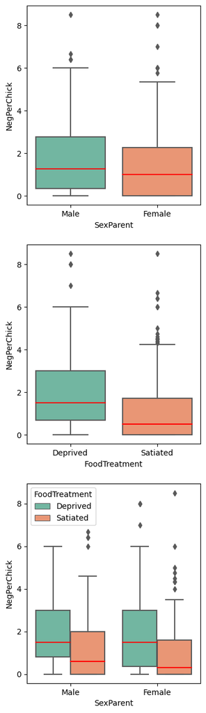

```python
#plotting
import matplotlib.pyplot as plt
import seaborn as sns

#creating 3 plots
fig, axs = plt.subplots(nrows=3,ncols=1,figsize=(4,16),dpi=100)
sns.boxplot(y=df['NegPerChick'],x=df['SexParent'], ax=axs[0],palette="Set2",medianprops={"color": "red"})
sns.boxplot(y=df['NegPerChick'],x=df['FoodTreatment'], ax=axs[1],palette="Set2",medianprops={"color": "red"})
sns.boxplot(y=df['NegPerChick'],x=df['SexParent'],hue=df['FoodTreatment'], ax=axs[2],palette="Set2",medianprops={"color": "red"})
```

Make a boxplot showing NegPerChick conditional on Nest. Are there differences for NegPerChick across the nesting sites?

```python
fig, axs = plt.subplots(nrows=1,ncols=1,figsize=(50,25),dpi=500)
sns.boxplot(y=df['NegPerChick'],x=df['Nest'],palette="Set2",medianprops={"color": "red"})
```

[figure not shown]

**There are differences across the nesting sites, some having larger range, or containing outliers or having medians completely out of other nesting sites.**

Make a scatterplot showing the relation between NegPerChick and SiblingNegotiation. Is there an association between these features?

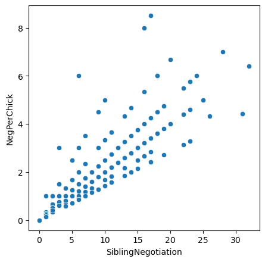

```python
fig, axs = plt.subplots(nrows=1,ncols=1,figsize=(5,5),dpi=100)
sns.scatterplot(y=df['NegPerChick'],x=df['SiblingNegotiation'],palette="Set2")
```

**There appears to be a somewhat positive relationship between SiblingNegotiation and NegPerChick. But moreso a heteroscedastic appearance to the scatter plot which could lead to inefficient predictions on the data.**

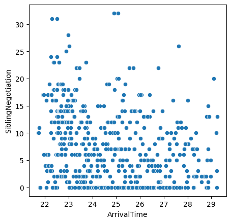

```python
fig, axs = plt.subplots(nrows=1,ncols=1,figsize=(5,5),dpi=100)
sns.scatterplot(y=df['SiblingNegotiation'],x=df['ArrivalTime'],palette="Set2")
```